# Peer Graded Assignment - Course Project 1

## Loading and preprocessing the data

As a part of preprocessing I converted date from character to Date Format

```r
setwd("F:\\Data Science\\My Codes and Assignments\\Coursera\\Reproducible research\\week 2\\Data")
DT <- read.csv("activity.csv")
DT$date <- as.Date(as.character(DT$date))
```

## What is mean total number of steps taken per day?

```r
library(dplyr)
```

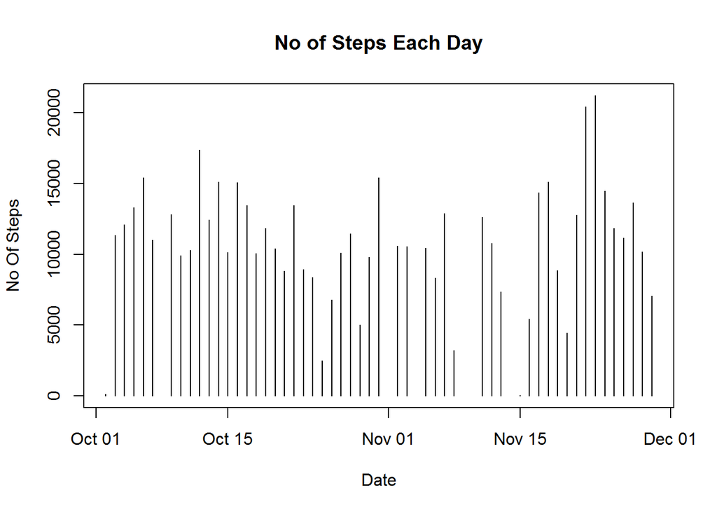

```r
DTcomplete <- na.omit(DT)
summarisedDT <- DTcomplete %>% group_by(date) %>% summarise(Tot.Steps = sum(steps))
plot(summarisedDT$date,summarisedDT$Tot.Steps,type = "h",xlab = "Date",ylab = "No Of Steps",main = "No of Steps Each Day")
```

Mean of No of steps per day:

```r
mean(summarisedDT$Tot.Steps,na.rm = TRUE)
```

```
## [1] 10766.19
```

Median of No of steps per day:

```r
median(summarisedDT$Tot.Steps)
```

```
## [1] 10765
```

## What is the average daily activity pattern?

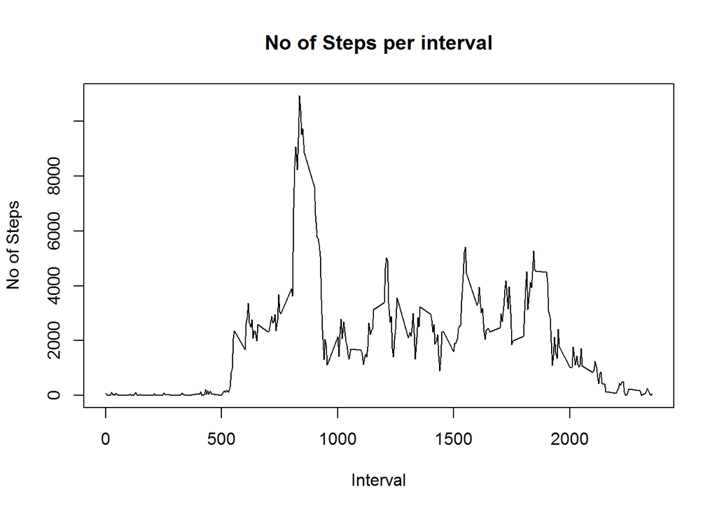

```r
library(dplyr)
DTcomplete <- na.omit(DT)
summarisedDataComplete <- DTcomplete %>% group_by(interval) %>% summarise(Tot.Steps = sum(steps))

plot(summarisedDataComplete$interval,summarisedDataComplete$Tot.Steps,type = "l",xlab = "Interval" ,ylab = "No of Steps",main = "No of Steps per interval")
```

The Interval With the maximum number of Steps

```r
lastRow<- tail(summarisedDataComplete[order(summarisedDataComplete$Tot.Steps),],1)
lastRow$interval
```

```
## [1] 835
```

## Inputing missing values

Number of missing values

```r
sum(is.na(DT))
```

```
## [1] 2304
```

Strategy For Finding out missing Values:

The Function Calculate Missing values calculates the missing value for that row which is he mean of the number of steps in that interval.

```r
calculateMissingValue <- function(dataSet,rowIndex)
{
  row <- dataSet[rowIndex,]
  subsetOfThisInterval <- subset(dataSet,dataSet$interval == row$interval,select = c("steps"))
  return(round(mean(subsetOfThisInterval$steps,na.rm = TRUE)))
}
```

The Function ReturnMissingFilledDataSet fills creates a new dataset where missing values are filled based on the above strategy.

```r
ReturnMissingFilledDataSet <- function(dataSet)
{
dataFilledMissing <- data.frame(steps = numeric(),date = numeric(),interval=numeric())
for (i in 1:nrow(dataSet)) {
  row <- dataSet[i,]
  if(is.na(row$steps))
  {
    dataFilledMissing[i,] = c(calculateMissingValue(dataSet,i),row$date,row$interval)
    next()
  }
  dataFilledMissing[i,] = c(row$steps,row$date,row$interval)
}
return(dataFilledMissing)
}


dataNAFilled = ReturnMissingFilledDataSet(DT)
dataNAFilled$date = as.Date(dataNAFilled$date, origin="1970-01-01")
```

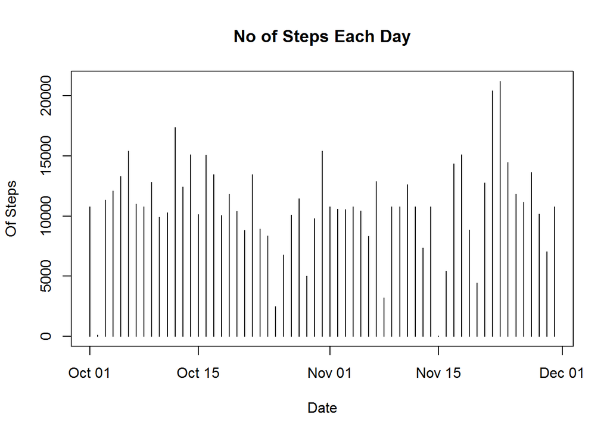

```r
summarisedDT <- dataNAFilled %>% group_by(date) %>% summarise(Tot.Steps = sum(steps))
summarisedDT$date <- as.Date(as.character(summarisedDT$date))
plot(summarisedDT$date,summarisedDT$Tot.Steps,type = "h",xlab = "Date",ylab = "No
Of Steps",main = "No of Steps Each Day")
```

Comarison of Medians They do differ slightly because of a wisely chosen strategy

```r
summarisedDTNaFilled <- dataNAFilled %>% group_by(date) %>% summarise(Tot.Steps =  sum(steps))

DTcomplete <- na.omit(DT)
summarisedDTComplete <- DTcomplete %>% group_by(date) %>% summarise(Tot.Steps =
sum(steps))


median(summarisedDTNaFilled$Tot.Steps)
```

```
## [1] 10762
```

```r
median(summarisedDTComplete$Tot.Steps)
```

```
## [1] 10765
```

Comparison of Means

```r
mean(summarisedDTNaFilled$Tot.Steps)
```

```
## [1] 10765.64
```

```r
mean(summarisedDTComplete$Tot.Steps)
```

```
## [1] 10766.19
```

## Are there differences in activity patterns between weekdays and weekends?

Creating a new factor indicating whether weekend or weekday

```r
library(dplyr)
weekDays <- c("Monday","Tuesday","Wednesday","Thursday","Friday")
weekEndDays<- c("Saturday","Sunday")
DT <- mutate(DT,DayOfWeek = weekdays(DT$date))
DT<- mutate(DT,DayType = ifelse((DayOfWeek %in% weekDays), "WeekDay", ifelse((DayOfWeek %in% weekEndDays), "WeekEnd", 0)))
DT$DayType <- as.factor(DT$DayType)
head(DT)
```

```
##   steps       date interval DayOfWeek DayType
## 1    NA 2012-10-01        0    Monday WeekDay
## 2    NA 2012-10-01        5    Monday WeekDay
## 3    NA 2012-10-01       10    Monday WeekDay
## 4    NA 2012-10-01       15    Monday WeekDay
## 5    NA 2012-10-01       20    Monday WeekDay
## 6    NA 2012-10-01       25    Monday WeekDay
```

Panel Plot of Weekdays Vs Weekends

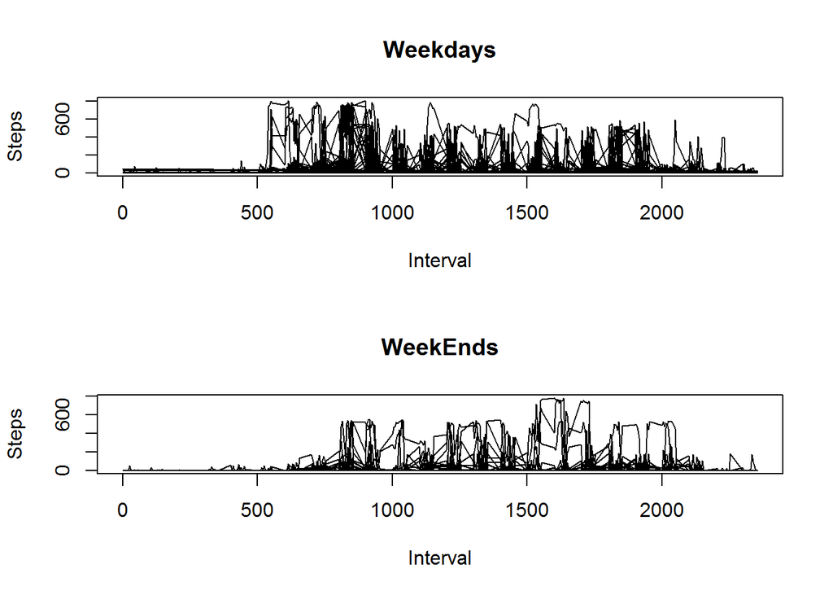

```r
dataWeekEnddays = subset(DT,DT$DayType=="WeekEnd")
dataWeekdays = subset(DT,DT$DayType=="WeekDay")
par(mfrow=c(2,1))
plot(dataWeekdays$interval,dataWeekdays$steps,type = "l",main = "Weekdays",ylab = "Steps",xlab = "Interval")
plot(dataWeekEnddays$interval,dataWeekEnddays$steps,type = "l",main = "WeekEnds",ylab = "Steps",xlab = "Interval")
```